# SegundoParcial

Carlos Carbone

6/14/2021

# Teoria

## 1) Una investigadora supone el siguiente modelo:

$$Y=\beta_0+\beta_1*X_1+\beta_2*X_2+\beta_3*X_3+v_i$$
a) Que ocurre si la correlacion entre $X_2$ y $X_3$ es igual a 1 $(\rho=1)$. Comente detalladamente b) Que ocurriria si la correlacion entre $X_2$ y $X_3$ es cercana a 0.99. Comente detalladamente.

### a.

Si la correlacion es 1 las variables regresoras estan correlacionadas perfectamente, es decir, existe multicolinealidad. Esto es basicamente que una de las variables es un multiplo de la otra por ejemplo, estaría sobrando una variable. Al haber multicolinealidad no voy a poder calcular los $\beta_i$ con la matriz inversa puesto que su determinante va a ser igual a cero.

### b.

Una correlacion alta implicaria una alta multicolinealidad si bien puedo obtener los $\beta_i$ estos van a ser poco eficientes y van a dar errores altos.

## 2) Una investigadora supone el siguiente modelo:

$$Y=\beta_0+\beta_1*X_1+\beta_2*X_2+u_i$$
a) Que test utilizaria para corroborar si hay o no heterocedasticidad? Explique el procedmiento del test. Proponga los dos caminos para solucionar en caso de no existir homocedasticidad.

2. Suponga que el verdadero modelo es:
   $$Y=\beta_0+\beta_1*X_1+\beta_2*X_2+\beta_3*X_3+e_i$$
   donde $X_3$ es una variable relevante del modelo. Que ocurre?

### a.

Homocedasticidad implica varianza consntate.

El test que utilizaria es el test de white. En dicho test lo que se hace es hacer una regresion tradicional con el modelo dado. Luego se obtienen los errores $u_i^2$ de esta primer regresion (errores al cuadrado). Luego se hace una regresión lineal multiple en funcion del cuadrado de los errores y las variables $X_i$, $X_i^2$ y $X_i * X_j$ (las cruzadas). En terminos de ecuacion queda algo asi:

$$\hat u_i^2=\alpha_0+\alpha_1 X_{1i}+\alpha_2 X_{2i}+\alpha_3 X_{1i}^2++\alpha_4 X_{2i}^2++\alpha_3 X_{1i}*X_{2i}+v_i$$
Para terminar se hace una prueba de significancia global (F) con gl=2 donde la $H_0$: homocedasticidad y la $H_a$ es heterocedasticidad.

Si no existe homocedasticidad tomamos dos caminos: 1) Si conocemos $\sigma_i^2$ usamos el metodo de MCG 2) Si no conocemos $\sigma_i^2$ usamos los errores robustos de white, que es construir la matriz $\Omega$ con los errores estimados $\hat u$.

### b.

Si $X_3$ es una variable relvante del modelo lo que va a suceder es que mi regresion anterior va a estar llevando esa variable a $u_i$ es decir a tomar parte del error. Se esta haciendo un subajuste del modelo. En este caso ahora los estimadores son eficientes cuando antes (con la variable omitida) eran sesgados e inconsistentes.

## 3

El logaritmo del ingreso mensual viene dado por
$$ln(w_i)=2.17+0.408 *Ed-0.0038896*Ed^2+u_i$$

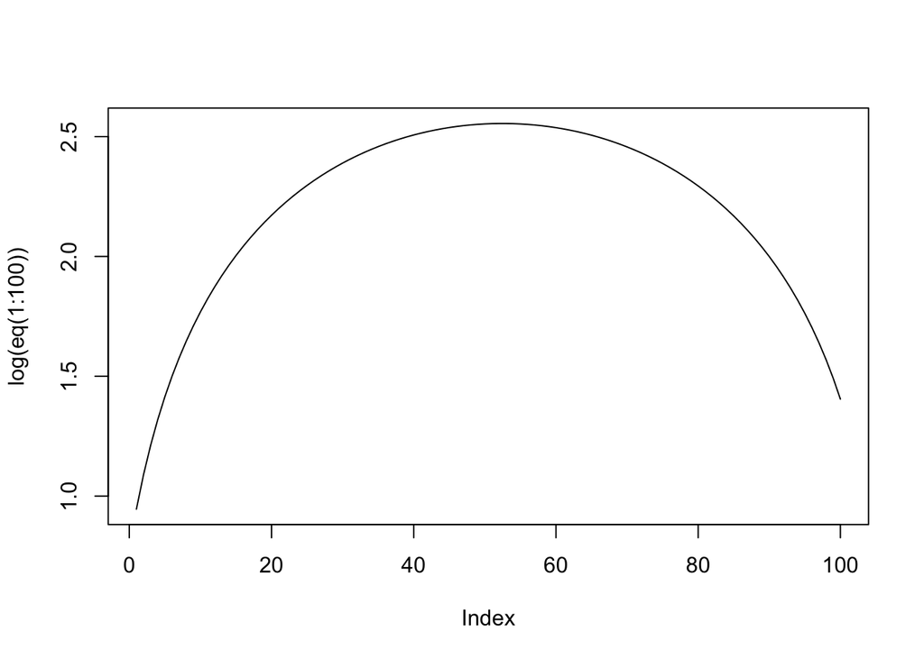

```r
eq<-function(x){2.17+0.408*x-0.0038896*x^2}
plot(log(eq(1:100)),type='l')
```

```r
deriv(~2.17+0.408*x-0.0038896*x^2,"x")
```

```
## expression({
##     .value <- 2.17 + 0.408 * x - 0.0038896 * x^2
##     .grad <- array(0, c(length(.value), 1L), list(NULL, c("x")))
##     .grad[, "x"] <- 0.408 - 0.0038896 * (2 * x)
##     attr(.value, "gradient") <- .grad
##     .value
## })
```

```r
polyroot(c(0.408,-0.0038896*2))
```

```
## [1] 52.44755+0i
```

Derivando e igualando a cero obtenemos el punto donde se hace máximo.

```r
deriv(~2.17+0.408*x-0.0038896*x^2,"x")
```

```
## expression({
##     .value <- 2.17 + 0.408 * x - 0.0038896 * x^2
##     .grad <- array(0, c(length(.value), 1L), list(NULL, c("x")))
##     .grad[, "x"] <- 0.408 - 0.0038896 * (2 * x)
##     attr(.value, "gradient") <- .grad
##     .value
## })
```

```r
polyroot(c(0.408,-0.0038896*2))
```

```
## [1] 52.44755+0i
```

# Practica

## Punto 1

Suponga que esta interesado en estimar:

$$Y_i=\beta_0+\beta_1*X_i+\epsilon_i$$
### a)

Estimamos la regresion a traves de MCO

```r
library(stargazer)
x= c(1,1,2,2,3,3,4,4,5,5)
y= c(10,20,10,40,20,60,20,80,30,100)
datos_punto1<-data.frame(x,y)
regression_mco<-lm(y~.,data=datos_punto1)

stargazer(regression_mco,type="text")
```

```
##
## ===============================================
##                         Dependent variable:
##                     ---------------------------
##                                  y
## -----------------------------------------------
## x                             12.500*
##                               (5.898)
##
## Constant                       1.500
##                              (19.560)
##
## -----------------------------------------------
## Observations                    10
## R2                             0.360
## Adjusted R2                    0.280
## Residual Std. Error       26.375 (df = 8)
## F Statistic             4.492* (df = 1; 8)
## ===============================================
## Note:               *p<0.1; **p<0.05; ***p<0.01
```

```r
summary(regression_mco)
```

```
##
## Call:
## lm(formula = y ~ ., data = datos_punto1)
##
## Residuals:
##    Min     1Q Median     3Q    Max
## -34.00 -18.38   1.00  19.12  36.00
##
## Coefficients:
##             Estimate Std. Error t value Pr(>|t|)
## (Intercept)    1.500     19.560   0.077   0.9408
## x             12.500      5.898   2.120   0.0669 .
## ---
## Signif. codes:  0 '***' 0.001 '**' 0.01 '*' 0.05 '.' 0.1 ' ' 1
##
## Residual standard error: 26.37 on 8 degrees of freedom
## Multiple R-squared:  0.3596, Adjusted R-squared:  0.2796
## F-statistic: 4.492 on 1 and 8 DF,  p-value: 0.06688
```

El coeficiente $\beta_1$ es significativa al 10% y no sigfnificativa al 5% y al 1%. La constante no es significativa El modelo global es significativo al 10% solamente. La variacion en una unidad de X implica una variacion de 12.5 unidades en y.

### b)

Hacemos el test de breuch Pagan para ver si hay Heterocedasticidad.

```r
library(lmtest)
bptest(regression_mco)
```

```
##
##  studentized Breusch-Pagan test
##
## data:  regression_mco
## BP = 9.4697, df = 1, p-value = 0.002089
```

La $H_0$ es que hay Homocedasticidad como el p-value es significativo al %5 entonces RHN y por lo tanto hay heterocedasticidad, es decir, la media de los errores no es constante.

### C)

Estimamos el la varianza a través de los errores robustos de white.

Desvio estandar de los coeficientes a traves de MCO

```r
coeftest(regression_mco)
```

```
##
## t test of coefficients:
##
##             Estimate Std. Error t value Pr(>|t|)
## (Intercept)   1.5000    19.5600  0.0767  0.94076
## x            12.5000     5.8976  2.1195  0.06688 .
## ---
## Signif. codes:  0 '***' 0.001 '**' 0.01 '*' 0.05 '.' 0.1 ' ' 1
```

Desvio estandar de los coeficientes a traves de white

```r
library(car)
coeftest(regression_mco,vcov=hccm)
```

```
##
## t test of coefficients:
##
##             Estimate Std. Error t value Pr(>|t|)
## (Intercept)   1.5000    16.5107  0.0908   0.9298
## x            12.5000     7.6758  1.6285   0.1421
```

### d)

Suponiendo que:
$$\sigma_i^2=\sigma^2*X_i^3$$
dividimos todo por $\sigma_i= \sqrt{ (X_i^3)}$ lo que nos deja la siguiente ecuacion:

$$\frac{Y}{\sqrt(X_i^3)}=\frac{\beta_0}{\sqrt(X_i^3)}+\beta_1 * \frac{\sqrt(X_i)}{X_i}+\frac{u_i}{\sqrt(X_i^3)}$$
Hacemos la nueva regresion PO EL ORIGEN

```r
datos_punto1$nuevaY=datos_punto1$y/sqrt(datos_punto1$x^3)
# datos_punto1$nuevaX=sqrt(datos_punto1$x)/datos_punto1$x
datos_punto1$nuevaX=datos_punto1$x/sqrt(datos_punto1$x^3)
datos_punto1$unoSobreRaizCubo=1/sqrt(datos_punto1$x^3)

regresion_ajustada<-lm(nuevaY~0+nuevaX+unoSobreRaizCubo,data = datos_punto1)

summary(regresion_ajustada)
```

```
##
## Call:
## lm(formula = nuevaY ~ 0 + nuevaX + unoSobreRaizCubo, data = datos_punto1)
##
## Residuals:
##     Min      1Q  Median      3Q     Max
## -5.8851 -3.7163  0.2719  4.0468  5.1257
##
## Coefficients:
##                  Estimate Std. Error t value Pr(>|t|)
## nuevaX             11.771      4.921   2.392   0.0437 *
## unoSobreRaizCubo    3.103      6.829   0.454   0.6616
## ---
## Signif. codes:  0 '***' 0.001 '**' 0.01 '*' 0.05 '.' 0.1 ' ' 1
##
## Residual standard error: 4.804 on 8 degrees of freedom
## Multiple R-squared:  0.8248, Adjusted R-squared:  0.781
## F-statistic: 18.83 on 2 and 8 DF,  p-value: 0.0009416
```

En terminos del problema no tiene interceptores. Una de de las dos variables es significativa al 5% y no al 1% y la otra variable no es significativa. Ademas el modelo global es es signficativo asi como tambien la R^2 ajustada explica el 78.1% de los resultados.

## Punto 2

1. Que significa que se usaran errores corregidos por White significa que existía heterocedasticidad. Eso significa que la varianza la calculamos como
   $$var(\hat\beta)=(X^TX)^{-1} * X^T *\hat u_i \hat u_i^t * X (X^TX)^{-1}$$

### b) Cual es la categoria base para el modelo c?

Categoria base para el modelo C es mujer sin estudios.